# Predicting Loans Repayment

Trung Le

June 25, 2016

# Introduction

In the lending industry, investors provide loans to borrowers in exchange for the promise of repayment with interest. If the borrower repays the loan, then the lender profits from the interest. However, if the borrower is unable to repay the loan, then the lender loses money. Therefore, lenders face the problem of predicting the risk of a borrower being unable to repay a loan.

To address this problem, we will use publicly available data from LendingClub.com, a website that connects borrowers and investors over the Internet. This dataset represents 9,578 3-year loans that were funded through the LendingClub.com platform between May 2007 and February 2010. The binary dependent variable “not_fully_paid” indicates that the loan was not paid back in full (the borrower either defaulted or the loan was “charged off,” meaning the borrower was deemed unlikely to ever pay it back).

To predict this dependent variable, we will use the following independent variables available to the investor when deciding whether to fund a loan:

**credit.policy**: 1 if the customer meets the credit underwriting criteria of LendingClub.com, and 0 otherwise.

**int.rate**: The interest rate of the loan, as a proportion (a rate of 11% would be stored as 0.11). Borrowers judged by LendingClub.com to be more risky are assigned higher interest rates.

**installment**: The monthly installments ($) owed by the borrower if the loan is funded.

**log.annual.inc**: The natural log of the self-reported annual income of the borrower.

**dti**: The debt-to-income ratio of the borrower (amount of debt divided by annual income).

**fico**: The FICO credit score of the borrower.

**days.with.cr.line**: The number of days the borrower has had a credit line.

**revol.bal**: The borrower’s revolving balance (amount unpaid at the end of the credit card billing cycle).

**revol.util**: The borrower’s revolving line utilization rate (the amount of the credit line used relative to total credit available).

**inq.last.6mths**: The borrower’s number of inquiries by creditors in the last 6 months.

**delinq.2yrs**: The number of times the borrower had been 30+ days past due on a payment in the past 2 years.

**pub.rec**: The borrower’s number of derogatory public records (bankruptcy filings, tax liens, or judgments).

## Preparing the Dataset

```r
loans <- read.csv("loans.csv")
table(loans$not.fully.paid)
```

```
##
##    0    1
## 8045 1533
```

```r
summary(loans)
```

```
##  credit.policy                 purpose        int.rate
##  Min.   :0.000   all_other         :2331   Min.   :0.0600
##  1st Qu.:1.000   credit_card       :1262   1st Qu.:0.1039
##  Median :1.000   debt_consolidation:3957   Median :0.1221
##  Mean   :0.805   educational       : 343   Mean   :0.1226
##  3rd Qu.:1.000   home_improvement  : 629   3rd Qu.:0.1407
##  Max.   :1.000   major_purchase    : 437   Max.   :0.2164
##                  small_business    : 619
##   installment     log.annual.inc        dti              fico
##  Min.   : 15.67   Min.   : 7.548   Min.   : 0.000   Min.   :612.0
##  1st Qu.:163.77   1st Qu.:10.558   1st Qu.: 7.213   1st Qu.:682.0
##  Median :268.95   Median :10.928   Median :12.665   Median :707.0
##  Mean   :319.09   Mean   :10.932   Mean   :12.607   Mean   :710.8
##  3rd Qu.:432.76   3rd Qu.:11.290   3rd Qu.:17.950   3rd Qu.:737.0
##  Max.   :940.14   Max.   :14.528   Max.   :29.960   Max.   :827.0
##                   NA's   :4
##  days.with.cr.line   revol.bal         revol.util     inq.last.6mths
##  Min.   :  179     Min.   :      0   Min.   :  0.00   Min.   : 0.000
##  1st Qu.: 2820     1st Qu.:   3187   1st Qu.: 22.70   1st Qu.: 0.000
##  Median : 4140     Median :   8596   Median : 46.40   Median : 1.000
##  Mean   : 4562     Mean   :  16914   Mean   : 46.87   Mean   : 1.572
##  3rd Qu.: 5730     3rd Qu.:  18250   3rd Qu.: 71.00   3rd Qu.: 2.000
##  Max.   :17640     Max.   :1207359   Max.   :119.00   Max.   :33.000
##  NA's   :29                          NA's   :62       NA's   :29
##   delinq.2yrs         pub.rec       not.fully.paid
##  Min.   : 0.0000   Min.   :0.0000   Min.   :0.0000
##  1st Qu.: 0.0000   1st Qu.:0.0000   1st Qu.:0.0000
##  Median : 0.0000   Median :0.0000   Median :0.0000
##  Mean   : 0.1638   Mean   :0.0621   Mean   :0.1601
##  3rd Qu.: 0.0000   3rd Qu.:0.0000   3rd Qu.:0.0000
##  Max.   :13.0000   Max.   :5.0000   Max.   :1.0000
##  NA's   :29        NA's   :29
```

```r
sum(is.na(loans))
```

```
## [1] 182
```

```r
missing = subset(loans, is.na(log.annual.inc)|is.na(days.with.cr.line)|is.na(revol.util)|is.na(inq.last.6mths)|is.na(delinq.2yrs)|is.na(pub.rec))
table(missing$not.fully.paid)
```

```
##
##  0  1
## 50 12
```

```r
loans_imputed = read.csv("loans_imputed.csv")
set.seed(144)
library(caTools)
split = sample.split(loans_imputed$not.fully.paid, SplitRatio = 0.7)
train = subset(loans_imputed, split == T)
test = subset(loans_imputed, split == F)
```

## Build and Predicting Model

```r
model = glm(not.fully.paid~., data = train, family = binomial)
summary(model)
```

```
##
## Call:
## glm(formula = not.fully.paid ~ ., family = binomial, data = train)
##
## Deviance Residuals:
##     Min       1Q   Median       3Q      Max
## -2.2049  -0.6205  -0.4951  -0.3606   2.6397
##
## Coefficients:
##                             Estimate Std. Error z value Pr(>|z|)
## (Intercept)                9.187e+00  1.554e+00   5.910 3.42e-09 ***
## credit.policy             -3.368e-01  1.011e-01  -3.332 0.000861 ***
## purposecredit_card        -6.141e-01  1.344e-01  -4.568 4.93e-06 ***
## purposedebt_consolidation -3.212e-01  9.183e-02  -3.498 0.000469 ***
## purposeeducational         1.347e-01  1.753e-01   0.768 0.442201
## purposehome_improvement    1.727e-01  1.480e-01   1.167 0.243135
## purposemajor_purchase     -4.830e-01  2.009e-01  -2.404 0.016203 *
## purposesmall_business      4.120e-01  1.419e-01   2.905 0.003678 **
## int.rate                   6.110e-01  2.085e+00   0.293 0.769446
## installment                1.275e-03  2.092e-04   6.093 1.11e-09 ***
## log.annual.inc            -4.337e-01  7.148e-02  -6.067 1.30e-09 ***
## dti                        4.638e-03  5.502e-03   0.843 0.399288
## fico                      -9.317e-03  1.710e-03  -5.448 5.08e-08 ***
## days.with.cr.line          2.371e-06  1.588e-05   0.149 0.881343
## revol.bal                  3.085e-06  1.168e-06   2.641 0.008273 **
## revol.util                 1.839e-03  1.535e-03   1.199 0.230722
## inq.last.6mths             8.437e-02  1.600e-02   5.275 1.33e-07 ***
## delinq.2yrs               -8.320e-02  6.561e-02  -1.268 0.204762
## pub.rec                    3.300e-01  1.139e-01   2.898 0.003756 **
## ---
## Signif. codes:  0 '***' 0.001 '**' 0.01 '*' 0.05 '.' 0.1 ' ' 1
##
## (Dispersion parameter for binomial family taken to be 1)
##
##     Null deviance: 5896.6  on 6704  degrees of freedom
## Residual deviance: 5485.2  on 6686  degrees of freedom
## AIC: 5523.2
##
## Number of Fisher Scoring iterations: 5
```

```r
pred = predict(model, type = 'response', newdata = test)
summary(pred)
```

```
##    Min. 1st Qu.  Median    Mean 3rd Qu.    Max.
## 0.02114 0.09461 0.13700 0.15780 0.19660 0.95370
```

```r
test$pred = pred
table(test$not.fully.paid, test$pred > 0.5)
```

```
##
##     FALSE TRUE
##   0  2400   13
##   1   457    3
```

```r
table(test$not.fully.paid)
```

```
##
##    0    1
## 2413  460
```

```r
library("ROCR")
ROCRpred = prediction(test$pred,test$not.fully.paid)
as.numeric(performance(ROCRpred, "auc")@y.values)
```

```
## [1] 0.6720995
```

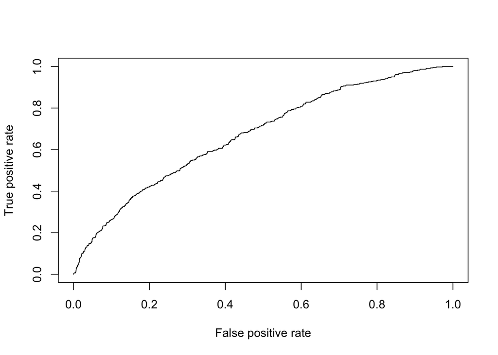

```r
ROCRperf = performance(ROCRpred, "tpr", "fpr")
plot(ROCRperf)
```